# Practice Data Analysis Results

Author

Marney Pratt

Published

September 24, 2026

## Save as

Before you get started, save this file as “dataIntro_YourName.qmd” where you replace YourName with your actual name (no spaces).

## Load necessary packages

Run the code below at the start of the session to make sure all the necessary packages are loaded.

It is recommended that you put all your code to load packages in one R chunk at the start. Run the chunk below by clicking the little green arrow at the top right of the code chunk.

```r
suppressPackageStartupMessages(
  library(tidyverse)) ## for readr, dplyr, ggplot2
library(ggbeeswarm) ## for jittering points (you can remove this is you did not use a dotplot)
library(flextable) ## for making formatted tables that can be pasted into Word or Google Docs
library(rstatix) #pipe friendly framework for basic stats
library(ggpubr) #publication ready plots
library(labelled) #for labeling variables better
library(patchwork) #for adding plots together
```

## Import Data

Set your dependent variable (x.var) and independent variable (predictor) in the blanks below.

Run the code chunk below to import the data.

```r
hrvData <- read_csv("data/hrvData.csv",
                    col_types = cols(
                      test.period = col_factor(
                        levels = c("Baseline",
                                   "Exercise",
                                   "Recovery")),
                      startDateTime = col_datetime(
                        format = "%Y-%m-%d %H:%M")))

subjects <- read_csv("data/subjects.csv")

metadata <- read_csv("data/variable_metadata.csv")

#create variable labels using the labelled package
variable_labels <- metadata |>
  select(variable, variable_label) |>
  deframe()

#add labels to data
hrvData <- hrvData |>
  left_join(subjects) |>
  set_variable_labels(!!!variable_labels)

# for more help with labeling data see
# https://www.pipinghotdata.com/posts/2022-09-13-the-case-for-variable-labels-in-r/
```

Take a look at the dataset we just created by clicking on “hrvData” in the Environment tab in the upper right RStudio window.

hrvData is a tidy data spreadsheet. There are 20 columns and 45 observations in each column. Each column has a column name and a more descriptive label that we added using the `set_variable_labels` function from the `labelled` package.

Recall that each subject had their heart beats recorded during a 5 min baseline recording, during 5 minutes of exercise, and 5 minutes of recovery.

Next we will relabel some of our variables so they can easily be used with the template code and avoid rewriting the column names a lot of times.

Please **ONLY** replace things in the blanks as directed. Do not change anything else.

```r
#Define your variables and redefine your dataframe name here to avoid having to type them a lot

#replace the blank with the continuous variable of choice
cont.var <- "SDNN"

#replace the blank below with the categorical variable that is your factor (this is the grouping variable)
factor.var <- "test.period"

#replace the blank with the name of the column that contains your subject identifiers
subject.ID <- "subject"

#replace the blank with the name of your dataframe here
df <- hrvData
```

## Descriptive Statistics

Descriptive statistics are useful to understand your data including

- What is the measure of central tendency - or typical value (mean, median, mode)
- What is the dispersion - or amount of variability (SD, IQR (Q1-Q3), Range (min-max))
- What is the sample size within each group (N)

These values also are useful to know to make decisions about how to report your results. For example, the standard deviation (SD) gives the average amount of variability in the data and helps us determine how to round values appropriately. The minimum and maximum values can help you determine what the best values would be for your axis limits on a graph.

Let’s calculate the descriptive statistics for your HRV variable of interest. Since we already defined the continuous dependent variable once as `cont.var` we can use `.data[[cont.var]]` to put that variable in each function so we don’t have to type the variable name a bunch of times.

Run the code below without changing anything in it

```r
# the code below will calculate descriptive statistics for the continuous variable of interest grouped by a categorical variable

df.sum <- df  |>
  # remove missing values from continuous variable
  filter(!is.na(.data[[cont.var]])) |>

  # Group the data by your categorical variable
  group_by(.data[[factor.var]]) |>

  # calculate the descriptive stats
  summarize(mean = mean(.data[[cont.var]]),
            median = median(.data[[cont.var]]),
            SD = sd(.data[[cont.var]]),
            IQR = IQR(.data[[cont.var]]),
            min = min(.data[[cont.var]]),
            max = max(.data[[cont.var]]),
            N = n())

df.sum
```

```
# A tibble: 3 × 8
  test.period  mean median    SD   IQR   min   max     N
  <fct>       <dbl>  <dbl> <dbl> <dbl> <dbl> <dbl> <int>
1 Baseline     67.6   64.1  24.7  30.8  33.7  113.    15
2 Exercise    130.   127.   47.5  65.5  49.2  250.    15
3 Recovery     67.6   66.2  26.2  31.5  15.9  124.    15
```

If the output is hard to read because of a smaller screen, try clicking the “Show in New Window” pop-out icon in the upper right of the output to open the output in its own window.

How do we report these values? We have to round appropriately and include the correct units as well as decide which subset of these values to report.

To help us decide which descriptive statistics to report, let’s see if the data has a normal distribution

### Test Assumption

First we will use a QQ plot to see if the distribution is normal

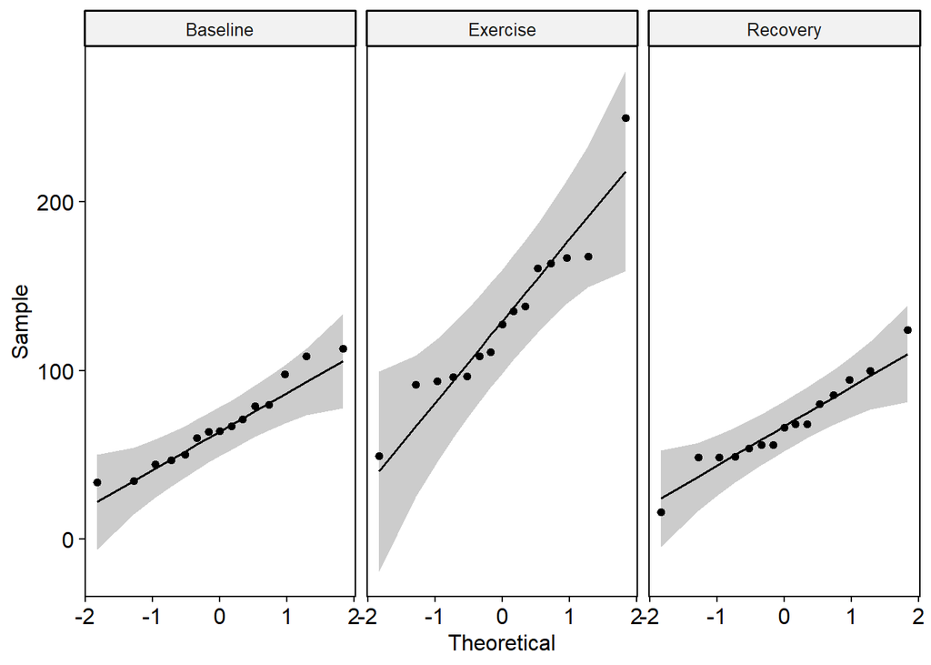

```r
#make a QQ plot for the continuous variable
#this tests to see if each group has a normal distribution
ggpubr::ggqqplot(
  data = df,                  #put the data frame here
  x = {{ cont.var }},            #put the continuous variable here
  facet.by = {{ factor.var }}  #put the factor variable here
)
```

Above shows a Q-Q plot (quantile-quantile plot) for each group comparing to a normal distribution in a graphical manner (see this [Complete Guide: How to Interpret Q-Q Plots](https://www.statology.org/qq-plot-interpretation/) if you want to learn more). If the data is normal, then the points are mostly aligned on the black line and within the gray shadded area (which is the 95% confidence interval).

Next, we will look for outliers.

```r
#test for outliers
df  |>
  group_by(.data[[factor.var]])  |>
  rstatix::identify_outliers({{ cont.var }})
```

```
 [1] test.period   subject       startDateTime min.HR        max.HR
 [6] avg.HR        RMSSD         SDNN          ln.RMSSD      pNN50
[11] mean.RR       total.power   LF.HF.ratio   LF.power      HF.power
[16] LF.peak       HF.peak       mean.HRV      age           gender
[21] is.outlier    is.extreme
<0 rows> (or 0-length row.names)
```

The result above shows how many rows (if any) contain outliers. If it says 0 rows, that would indicate that there were no outliers.

You may want to click on the little “Show in new window” icon at the top right of the results to see the whole table of results more easily. Either way, make sure you fully scroll to the right to see the last column in the results labeled “is.extreme”. If there are any extreme outliers, you may want to filter those subjects out and rerun the descriptive statistics.

If there are no extreme outliers, then delete the code chunk below. If there are outliers that you remove, you must note that you removed them and why in your results (you might want to look at the information about the subject to see if you can see why they were an outlier or make sure you wrote the values down correctly in the original spreadsheet)

```r
#if you want to remove an outlier
#fill in the blank with the number of the subject you want to remove


# df <- df |>
#   dplyr::filter(subject != 7)
#
#
#
# df.sum.outlierRemoved <- df  |>
#   # remove missing values from continuous variable
#   filter(!is.na(.data[[cont.var]])) |>
#
#   # Group the data by your categorical variable
#   group_by(.data[[factor.var]]) |>
#
#   # calculate the descriptive stats
#   summarize(mean = mean(.data[[cont.var]]),
#             median = median(.data[[cont.var]]),
#             SD = sd(.data[[cont.var]]),
#             IQR = IQR(.data[[cont.var]]),
#             min = min(.data[[cont.var]]),
#             max = max(.data[[cont.var]]),
#             N = n())
#
# df.sum.outlierRemoved
```

## Reporting Descriptive Statistics

It is not always necessary to give the values of the descriptive statistics. Especially in a presentation, you want to minimize text and it is usually better to show things visually (in a graph) rather than textually (in a table).

However, if you want to report any of the descriptive statistics, which ones should you report? If the data are close enough to a normal distribution, then you can report the mean and SD. If the data are not very normal, then use the median and IQR or range for the descriptive statistics (for smaller datasets, I usually recommend using the median and range).

We also need to decide how to round these values.

A good rule of thumb is to use the SD as the indicator of how much average variability there is in your data. Personally, I like to round the SD to 2 significant digits based on recommendations in [Cole et al. (2015)](https://www-ncbi-nlm-nih-gov.libproxy.smith.edu/pmc/articles/PMC4483789/). Then round all the other values to the same decimal place as the rounded SD.

Start by rounding the standard deviation (SD) to 2 SIGNIFICANT DIGITS.

We will use the `signif` function with `digits=2` to round the SD to 2 significant digits.

```r
# replace the blank with the cleaned data frame name
df  |>

  # replace the blank with the categorical variable(s)
  group_by(.data[[factor.var]]) |>

  # calculate the SD rounded to 2 significant digits
  summarize(SD = signif(sd(.data[[cont.var]]), digits=2))
```

```
# A tibble: 3 × 2
  test.period    SD
  <fct>       <dbl>
1 Baseline       25
2 Exercise       48
3 Recovery       26
```

To round other values (mean, median, quartiles, etc), round to the same DECIMAL place as the SD rounded to 2 significant figures. Rounding the SD tells us how variable the data are and how many decimals we can report to. Thus, look at what decimal place the SD was rounded to for 2 significant digits.

We will use the `round` function to round our values. This is what the help file says about the `round` function

“`round` rounds the values in its first argument to the specified number of decimal places (default 0). See ‘Details’ about “round to even” when rounding off a 5.

Rounding to a negative number of digits means rounding to a power of ten, so for example round(x, digits = -2) rounds to the nearest hundred.”

Use the following for digits in the `round` function

- rounding to the hundreds place use digits=-2
- rounding to the tens place use digits=-1
- rounding to the ones place use digits=0
- rounding to the tenths place use digits=1
- rounding to the hundredths place use digits=2

Now make a nice formatted table with values rounded and only the values you want to include. Open the “script templates” folder and find the script you want to use. Select everything in the script template (ctrl + A on Windows or cmd + A on Macs), then copy the selection (ctrl + C on Windows or cmd + C on Macs). Paste the script template in the code chunk below (make sure there is an empty row under the label)(ctrl + V on Windows or cmd + V on Macs).

Make sure to replace the blank in the script template with the proper rounding digit as indicated above. Don’t change anything else, just replace the one blank

```r
#set the number of digits to round to based on the rules above (this blank should be just a number)
round.digit <- 0

#calculate descriptive stats
#replace the blank below with the name of the dataframe
df.sum <- df |>

  # replace the blank with the categorical variable(s)
  group_by(.data[[factor.var]]) |>

  # remove missing values
  filter(!is.na(.data[[cont.var]])) |>

  #calculate the rounded values
  summarise(Mean = round(mean(.data[[cont.var]]), digits=round.digit),
            SD = signif(sd(.data[[cont.var]]), digits=2),
            N = n())

#create the formatted table
ft <- flextable(df.sum,
                cwidth = 0.75) |>  #can vary cell width as needed

  #bold the headings
  bold(part = "header") |>

  #center columns
  align(align = "center", part = "all" )

#print the table
#right click on the table, choose select all,
#choose copy, then paste in your document
#finish formatting as needed in your document
ft
```

| Testing Period | Mean | SD | N |
| --- | --- | --- | --- |
| Baseline | 68 | 25 | 15 |
| Exercise | 130 | 48 | 15 |
| Recovery | 68 | 26 | 15 |

```r
#calculate descriptive stats
#replace the blank below with the name of the dataframe
df.sum2 <- df |>

  # replace the blank with the categorical variable(s)
  group_by(.data[[factor.var]]) |>

  # remove missing values
  filter(!is.na(.data[[cont.var]])) |>

  #calculate the rounded values
  summarise(Median = round(median(.data[[cont.var]]), digits=round.digit),
            min = round(min(.data[[cont.var]]), digits=round.digit),
            max = round(max(.data[[cont.var]]), digits=round.digit),
            N = n()) |>
  mutate(Range = paste(min, max, sep = "-")) |>
  dplyr::select(-min, -max) |>
  relocate(N, .after = last_col())

#create the formatted table
ft2 <- flextable(df.sum2,
                cwidth = 0.75) |>  #can vary cell width as needed

  #bold the headings
  bold(part = "header") |>

  #center columns & autofit
  align(align = "center", part = "all" ) |>
  set_table_properties(layout = "autofit")

#print the table
#right click on the table, choose select all,
#choose copy, then paste in your document
#finish formatting as needed in your document
ft2
```

| Testing Period | Median | Range | N |
| --- | --- | --- | --- |
| Baseline | 64 | 34-113 | 15 |
| Exercise | 127 | 49-250 | 15 |
| Recovery | 66 | 16-124 | 15 |

## HRV Graph

First let’s graph the HRV variable.

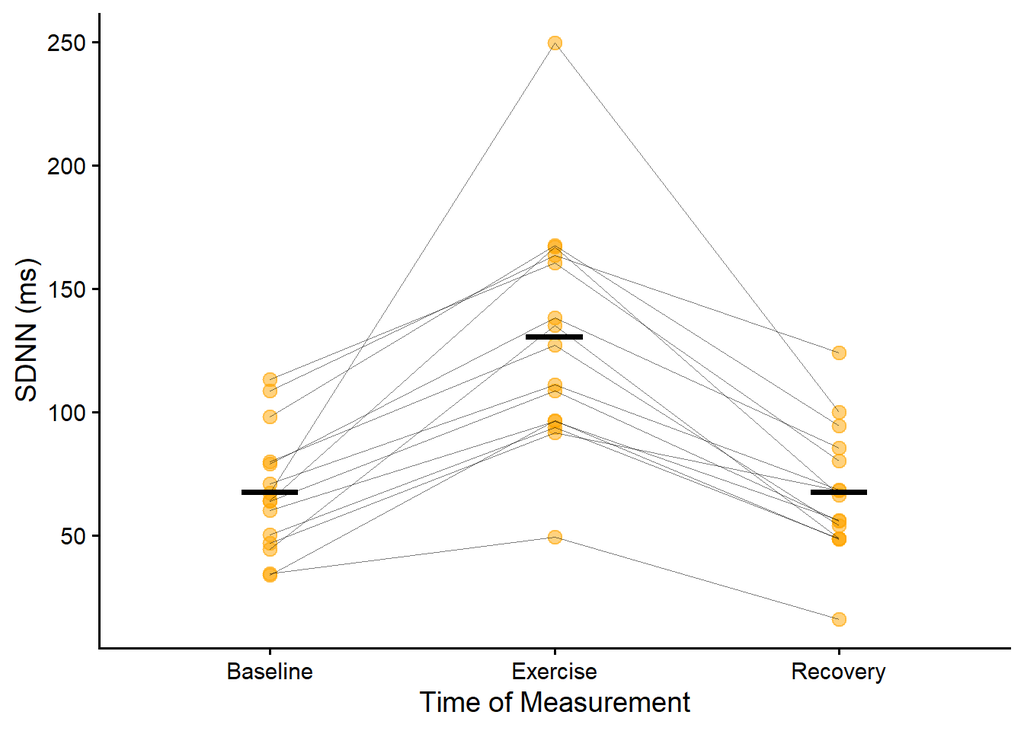

```r
#the code below creates a plot that connects the dots within subjects

line.plot <- df  |>
  ggplot(aes(
    x=.data[[factor.var]],
    y=.data[[cont.var]],
    group = .data[[subject.ID]])) +
  geom_point(size = 3,
             color = "orange",
             alpha = 0.5) +
  geom_line(linewidth = 0.2,
            alpha = 0.5) +
  stat_summary(fun = mean,         #change this to median if your data are not normal
               fun.min = mean,     #change this to median if your data are not normal
               fun.max = mean,     #change this to median if your data are not normal
               geom = "crossbar",
               color = "black",
               width = 0.2,
               linewidth = 0.5,
       aes(group = .data[[factor.var]] )) +

  #below gives you the nice labels for the axis titles
  #You can use spaces and capital letters here
  #see the "axis.labels.R" script template if you need superscripts
  xlab("Time of Measurement") +
  ylab("SDNN (ms)") +  #make sure to include units here as needed

  #additional formatting
  theme_classic(base_size = 14)  +  #sets the font size
  theme(legend.position = "none")   #controls legend/key

line.plot
```

Make sure you have included proper axis titles that include units where needed. Make sure to also use the correct measure of central tendency (mean if data are normal, median if data are not normal). You can change the stat_summary code above from mean to median as needed.

## Effect Size

You will learn much more about inferential statistics in a full statistics course. In this class, we are just going to discuss effect sizes. An effect size tells us how big the difference is between groups. A standardized effect size takes the difference between groups but also divides that difference by some measure of variability.

To pick the right test, we need to determine if the distribution is normal and if the variance is equal.

- **Normal Distribution, Equal Variance:** If the data is normal, and the two groups have similar dispersion (i.e. similar variance), then you should use “regular” **Cohen’s d effect size (*d*)**
- **Unequal Variance:** If the data has unequal dispersion (i.e. unequal variance), then you should use the **Cohen’s d for Welch test effect size (*d*)**
- **Non-normal Distribution, Equal Variance:** If the data is NOT normal but the two groups have similar dispersion (i.e. similar variance), then you should use the **Wilcoxon effect size (*r*)** (note that some statisticians recommend to use the Cohen’s d for Welch test effect size if the variance is very different even if the distribution is not normal)

Go to the script_templates folder and then the effectSize subfolder. Select the correct effect size based on your data. Select the entire script (control-A or command-A), copy it (control-C or command-C), paste it in the code chunk below (control-V or command-V), and then run it.

```r
#set the formula to use the defined variables
#this makes it easier to change the variables at the top and rerun everything
#without having to retype the variables in every code chunk
response <- cont.var
predictor <- factor.var
formula_string <- paste0(response, " ~ ", predictor)
formula_object <- as.formula(formula_string)


#standardized effect size for for paired data
#with normal distribution and equal variance
#Cohen's d
effectSize.results  <-
  rstatix::cohens_d(
    data = df,           #put the dataframe name here
    formula_object,      #continuous variable ~ factor (see above)
    paired = TRUE,       #TRUE for within-subjects, FALSE for between-subjects
    var.equal = TRUE,   #TRUE for equal variance, FALSE for unequal variance
    hedges.correction = TRUE,
    ci = TRUE,
    conf.level = 0.95,
    ci.type = "bca",
    nboot = 1000)

effectSize.results <- effectSize.results |>
  mutate(comparison = paste(group1, group2, sep = "-"))

effectSize.results
```

```
# A tibble: 3 × 10
  .y.   group1   group2    effsize    n1    n2 conf.low conf.high magnitude
  <chr> <chr>    <chr>       <dbl> <int> <int>    <dbl>     <dbl> <ord>
1 SDNN  Baseline Exercise -1.50       15    15    -2.65     -0.94 large
2 SDNN  Baseline Recovery  0.00115    15    15    -0.54      0.52 negligible
3 SDNN  Exercise Recovery  1.83       15    15     1.32      2.7  large
# ℹ 1 more variable: comparison <chr>
```

The effect size is the difference between typical values standardized by the amount of variation in the data (the exact equation depends on which effect size you use). The effect size here was calculated by taking 1000 bootstrapped random samples and the 95% confidence intervals were calculated with the adjusted bootstrap percentile (BCa) method.

The interpretation of the standardized effect size is included in the magnitude column - negligible, small, moderate, or large. This will help you determine if the difference between means or medians is meaningful or not. The 95% confidence intervals tells you how precisely the effect size was estimated. If the 95% confidence interval does not include zero, it suggests that the effect is statistically significant

**NoteOptional Additional Resources on Effect Sizes**

- How to use the `rstatix` package to calculate effect sizes
  - **Cohen’s d for Student t-test** on the [T-test Effect Size using Cohen’s d Measure](https://www.datanovia.com/en/lessons/t-test-effect-size-using-cohens-d-measure/) webpage
  - **Cohen’s d for Welch test** on the [T-test Effect Size using Cohen’s d Measure](https://www.datanovia.com/en/lessons/t-test-effect-size-using-cohens-d-measure/) webpage
  - **Effect size** under **Wilcoxon rank sum test** on the [Wilcoxon Test in R](https://www.datanovia.com/en/lessons/wilcoxon-test-in-r/) webpage
- To learn more about inferential tests to compare two groups
  - compare means with normal distribution: [t-Test](https://datatab.net/tutorial/t-test)
  - rank-sum test to compare two independent samples that are not normally distributed: [Mann-Whitney U-Test](https://datatab.net/tutorial/mann-whitney-u-test)
  - signed-rank test to compare paired groups that are not normally distributed: [Wilcoxon signed-rank test](https://datatab.net/tutorial/wilcoxon-test)
- [Alternatives to P value: confidence interval and effect size](https://pmc.ncbi.nlm.nih.gov/articles/PMC5133225/)

Let’s make a graph of the effect size results to make it more visual

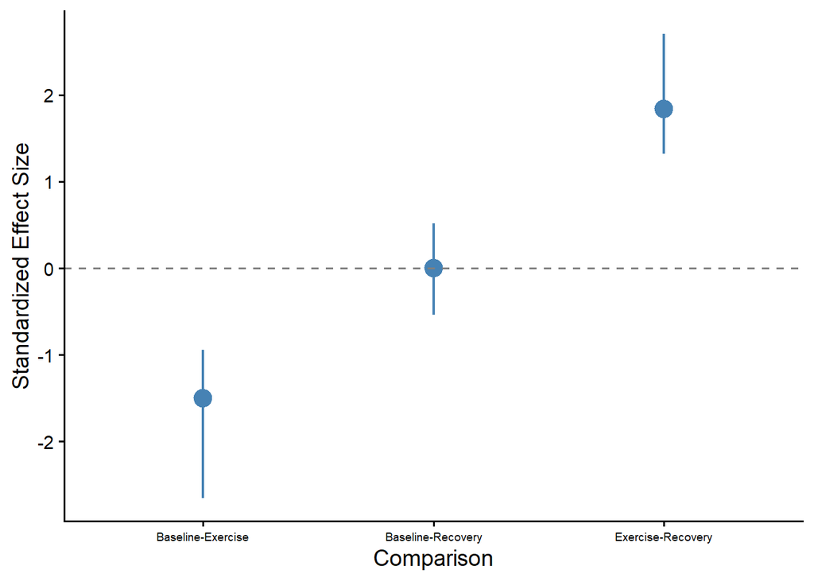

```r
effect.plot <- effectSize.results  |>
  ggplot(aes(
    x=comparison,
    y=effsize)) +

  geom_pointrange(aes(ymin = conf.low, ymax = conf.high),
                  size = 1, # Adjust point size
                  linewidth = 0.8, # Adjust line thickness
                  color = "steelblue") + # Set color
  geom_hline(yintercept = 0, linetype = "dashed", color = "grey50") + # Add a reference line at 0
  xlab("Comparison") +
  ylab("Standardized Effect Size") +
  #additional formatting
  theme_classic(base_size = 14)  +  #sets the font size
   theme(
    plot.title = element_text(size = 12),  #Set title size
    plot.subtitle = element_text(size = 12), #Set subtitle size
    axis.text.x = element_text(size = 7) #Set x axis label size
  ) +
  theme(legend.position = "none")   #controls legend/key

effect.plot
```

This shows the effect size results visually. In this case, the points represent the value of the effect size that you chose (Cohen’s d, Cohen’s d for Welch test, or the Wilcoxon paired signed-rank test) for three comparisons, and the vertical lines represent the 95% confidence interval calculated using the adjusted bootstrap percentile (BCa) method.

If the 95% CI includes zero (shown by crossing over the dotted line), then that effect size is not significantly different from zero (meaning there is no evidence of an effect).

## Join Original Graph and Effect Size Results

Now let’s make one image that joins your original graph with the effect size results graph together.

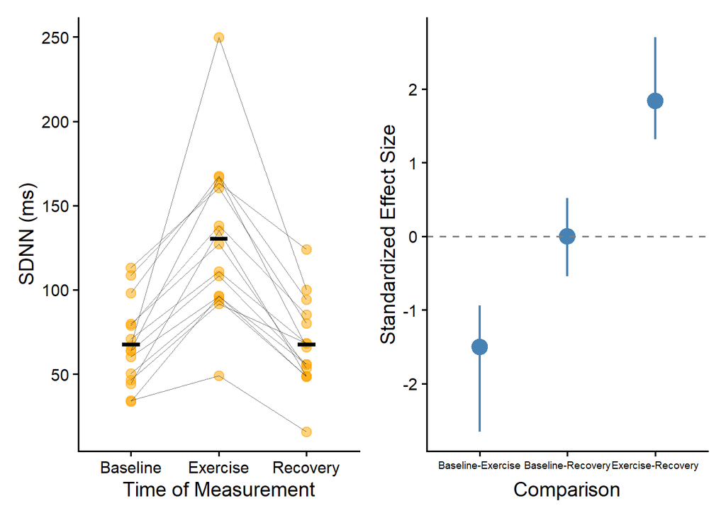

```r
patch.plot <- line.plot + effect.plot +
  plot_layout(widths = c(2, 2))

patch.plot
```

Let’s use `ggsave()` again to save a copy of the effect size graph.

```r
# save the graph
# recommended to use.png or .jpg file types
ggsave(filename = "results/practiceDataResults.png",
       plot = patch.plot,   #put the object name of your plot here
       height = 5, width = 8, units = "in",
       dpi = 300)
```

The above code will save your effect size graph you made and call it “practiceDataResults.png”. This file will appear in the results folder within dataIntro folder under the Files tab in the lower right quadrant of this window.

If you are working on the Smith server, you will first need to export this file to your computer:

- Check the box next to the “practiceDataResults.png” file
- Go to the “More” menu with the gear icon and click the drop down arrow
- Select “Export” and then save the file to your computer

You can now insert this graph into your Results slide (see the lab notebook entry for today for more details).

## Render this File to HTML & Print to PDF

Now that you are all done with this activity, complete the following:

- Save this Quarto file (make sure it has been renamed to “dataIntro_YourName.qmd”)
- Render this Quarto file to HTML (just select the Render menu item at the top of this window)
- If the HTML file didn’t already open in your browser, then click on the name of the file in the Files window and select “View in Web Browser”
- Once the HTML file is open in your web browser, then use the print function within your browser to save it or print it as a PDF
- Make sure the PDF file is saved somewhere on your computer that you can get to (as with the graph file above, you may first need to export this file to your computer if you are working on the Smith server)
- Place a copy of the PDF file in your Individual Google Drive folder for this class